# Customer Segmentation

25 August, 2022

### The transaction data for channel partners(customer) of a large FMCG company is available. The data available is for two years -by month of the year and brand. The marketing team wants to create segments of customers based on transaction pattern so that marketing strategies can be developed for each segment.

### Objective: To create segments of similar customers which can be used for marketing strategies

### Packages/Libraries required

```r
library(dplyr)
library(purrr)
library(flextable)
library(officer)
library(factoextra)
library(flexclust)
library(ggplot2)
```

### Data Description

| Column name | Column description |
| --- | --- |
| CustomerID | Customer ID for each customer |
| Month | Month of transaction |
| Brand | Brand purchased |
| Year | Year of transaction |
| Sales | Total sales in INR |

#### Following is a table of derived variables which are used in customer segmentation

| Column name | Column description |
| --- | --- |
| sales_21 | Total sales for year 2021 |
| sales_B121 | Total sales for the year 2021 only for brand B1(Coffee) |
| BuyingFreq_21 | Number of unique months of purchase in the year 2021 |
| BuyingFreq_B121 | Number of unique months of purchase of brand B1 in the year 2021 |
| BrandEng_21 | Number of unique brands of purchase in 2021 |
| B121_Contribution | Contribution of Brand b1 to total in 2021 = sales in b1 /total sales for each customer*100 |

#### Import the data “Transaction data for Segmentation” using read.csv function

```r
setwd("D:\\Sankhya")
df=read.csv("Transaction data for Segmentation.csv")
head(df)
```

```
  CustomerID Month Brand Year    Sales
1      10000     5    B4 2021 21830.69
2      10000    10    B5 2021  7221.56
3      10000     8    B1 2021 29684.44
4      10000    10    B3 2021  1573.06
5      10000     1    B2 2020  4016.70
6      10000     4    B2 2020 34689.10
```

#### Derive variable sales_21

```r
df1=df %>% group_by(CustomerID,Year) %>% summarise(sales_21 =sum(Sales)) %>%  filter(Year==2021) %>% select(-Year)
```

#### Derive variable sales_B121

```r
df2= df %>% filter(Year==2021, Brand=="B1") %>% group_by(CustomerID) %>% summarise(sales_B121 =sum(Sales))
```

#### Derive variable BuyingFreq_21

```r
df3= df %>% filter(Year==2021)  %>% group_by(CustomerID) %>% summarise(BuyingFreq_21 = n_distinct(Month))
```

#### Derive variable BuyingFreq_B121

```r
df4=df %>% filter(Year==2021, Brand=="B1")  %>% group_by(CustomerID) %>% summarise( BuyingFreq_B121= n_distinct(Month))
```

#### Derive variable BrandEng_21

```r
df5=df %>% filter(Year==2021)  %>% group_by(CustomerID) %>% summarise(BrandEng_21 = n_distinct(Brand))
```

#### Create masterdata by merging all defined variables

```r
masterdata<- left_join(df1, df2, by='CustomerID') %>% left_join(., df3, by='CustomerID')  %>% left_join(., df4, by='CustomerID') %>% left_join(., df5, by='CustomerID')
head(masterdata) %>% as.data.frame()
```

```
  CustomerID sales_21 sales_B121 BuyingFreq_21 BuyingFreq_B121 BrandEng_21
1      10000 60309.75   29684.44             3               1           4
2      10001 68859.11   26593.40             4               2           2
3      10004 69956.96    6824.23             3               1           3
4      10005  9233.57         NA             2              NA           2
5      10006 93586.85    7789.73             5               1           4
6      10008 33626.32         NA             2              NA           2
```

#### Derive variable B121_contribution

```r
masterdata$B121_Contribution=masterdata$sales_B121/masterdata$sales_21*100
head(masterdata)
```

```
# A tibble: 6 × 7
# Groups:   CustomerID [6]
  CustomerID sales_21 sales_B121 BuyingFreq_21 BuyingFreq_B121 BrandEn…¹ B121_…²
       <int>    <dbl>      <dbl>         <int>           <int>     <int>   <dbl>
1      10000   60310.     29684.             3               1         4   49.2
2      10001   68859.     26593.             4               2         2   38.6
3      10004   69957.      6824.             3               1         3    9.75
4      10005    9234.        NA              2              NA         2   NA
5      10006   93587.      7790.             5               1         4    8.32
6      10008   33626.        NA              2              NA         2   NA
# … with abbreviated variable names ¹BrandEng_21, ²B121_Contribution
```

#### Replace NA values with 0 since NA values are generated if there is no transaction

```r
masterdata[is.na(masterdata)] = 0
masterdata=data.frame(masterdata)
head(masterdata)
```

```
  CustomerID sales_21 sales_B121 BuyingFreq_21 BuyingFreq_B121 BrandEng_21
1      10000 60309.75   29684.44             3               1           4
2      10001 68859.11   26593.40             4               2           2
3      10004 69956.96    6824.23             3               1           3
4      10005  9233.57       0.00             2               0           2
5      10006 93586.85    7789.73             5               1           4
6      10008 33626.32       0.00             2               0           2
  B121_Contribution
1         49.219969
2         38.620017
3          9.754898
4          0.000000
5          8.323530
6          0.000000
```

#### Subset data by deleting CustomerID for clustering

```r
customer<-subset(masterdata,select=c(-CustomerID))
head(customer)
```

```
  sales_21 sales_B121 BuyingFreq_21 BuyingFreq_B121 BrandEng_21
1 60309.75   29684.44             3               1           4
2 68859.11   26593.40             4               2           2
3 69956.96    6824.23             3               1           3
4  9233.57       0.00             2               0           2
5 93586.85    7789.73             5               1           4
6 33626.32       0.00             2               0           2
  B121_Contribution
1         49.219969
2         38.620017
3          9.754898
4          0.000000
5          8.323530
6          0.000000
```

#### Standardise all variables using scale function

```r
data=scale(customer) %>% as.data.frame()
head(data)
```

```
     sales_21 sales_B121 BuyingFreq_21 BuyingFreq_B121 BrandEng_21
1  0.03426118  0.9533620     0.2824409       0.6018807   1.7162326
2  0.24221052  0.7913099     1.0597796       1.9874163  -0.2806892
3  0.26891395 -0.2451168     0.2824409       0.6018807   0.7177717
4 -1.20808422 -0.6028867    -0.4948978      -0.7836549  -0.2806892
5  0.84367277 -0.1944991     1.8371183       0.6018807   1.7162326
6 -0.61477006 -0.6028867    -0.4948978      -0.7836549  -0.2806892
  B121_Contribution
1         0.9964096
2         0.6407249
3        -0.3278534
4        -0.6551821
5        -0.3758834
6        -0.6551821
```

#### Create plot for elbow method to decide optimum no of clusters

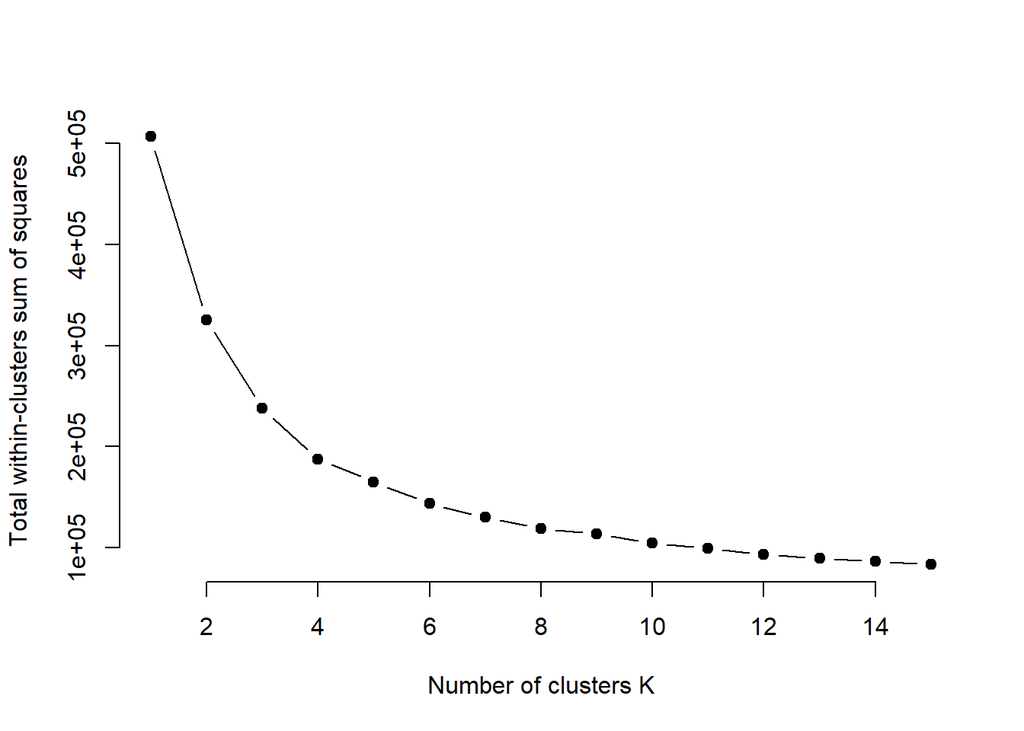

```r
wss <- function(k) {
  kmeans(data, k, nstart = 10 ,iter.max = 1000)$tot.withinss
}

 k.values <- 1:15

  wss_values <- map_dbl(k.values, wss)

 plot(k.values, wss_values,
      type="b", pch = 19, frame = FALSE,
      xlab="Number of clusters K",
      ylab="Total within-clusters sum of squares")
```

#### Comment : Using elbow method, K=4 clusters are finalised

#### set.seed() is used to ensure reproducibility of the results given by kmeans function

```r
set.seed(123)
k4<-kmeans(data,4)
```

#### Cluster size(No. of customers in each cluster)

```r
k4$size
```

```
[1] 11073 34017 13809 25495
```

#### Add cluster membership to the data

```r
masterdata$segment_mean<-k4$cluster
masterdata=data.frame(masterdata)
head(masterdata)
```

```
  CustomerID sales_21 sales_B121 BuyingFreq_21 BuyingFreq_B121 BrandEng_21
1      10000 60309.75   29684.44             3               1           4
2      10001 68859.11   26593.40             4               2           2
3      10004 69956.96    6824.23             3               1           3
4      10005  9233.57       0.00             2               0           2
5      10006 93586.85    7789.73             5               1           4
6      10008 33626.32       0.00             2               0           2
  B121_Contribution segment_mean
1         49.219969            1
2         38.620017            1
3          9.754898            4
4          0.000000            2
5          8.323530            4
6          0.000000            2
```

#### Visualising cluster solution using two principal components of variables used in the clustering algorithm

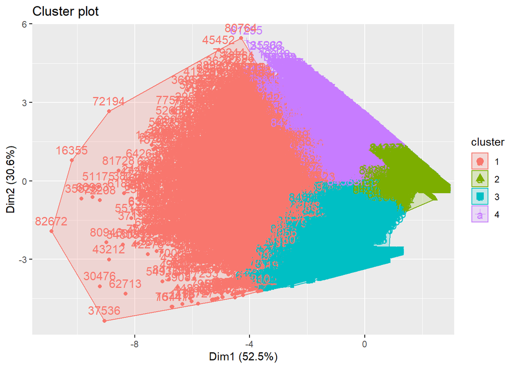

```r
fviz_cluster(k4, data = data)
```

#### Calculate mean of each variable clusterwise and round off values to two decimal places

```r
allmean=aggregate( cbind(sales_21,sales_B121,BuyingFreq_21,BuyingFreq_B121
                  ,BrandEng_21,B121_Contribution)~segment_mean,data=masterdata
                   ,FUN=mean)
allmean=allmean %>% map(round,2) %>% as.data.frame()
allmean
```

```
  segment_mean  sales_21 sales_B121 BuyingFreq_21 BuyingFreq_B121 BrandEng_21
1            1 113091.61   45137.59          4.14            1.63        3.33
2            2  33291.52     266.55          1.70            0.06        1.53
3            3  38928.06   25705.12          2.01            1.20        1.85
4            4  80353.30    4183.80          3.57            0.43        3.06
  B121_Contribution
1             42.55
2              0.87
3             71.41
4              6.32
```

#### Summarising each variables( average value) within each cluster

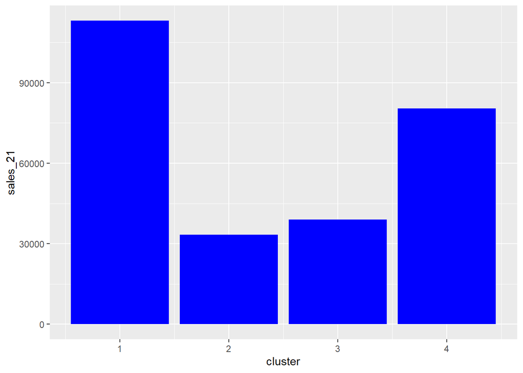

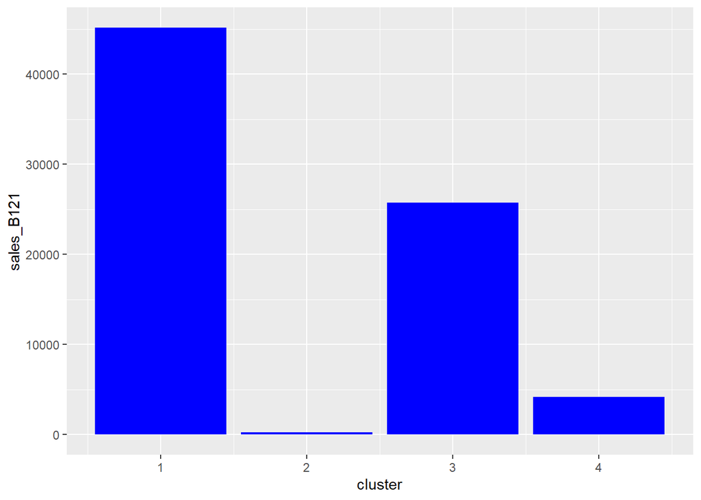

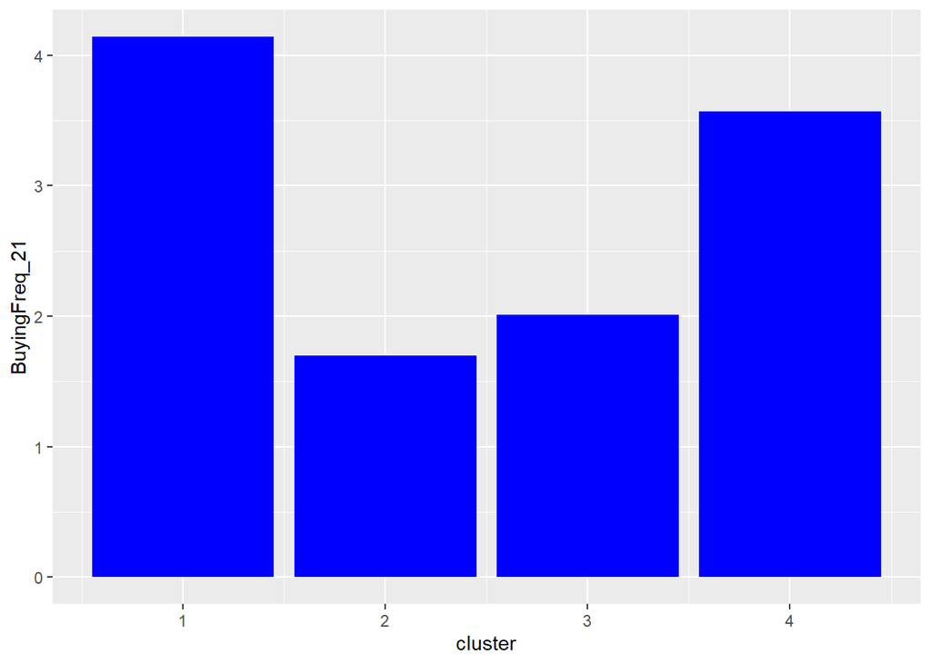

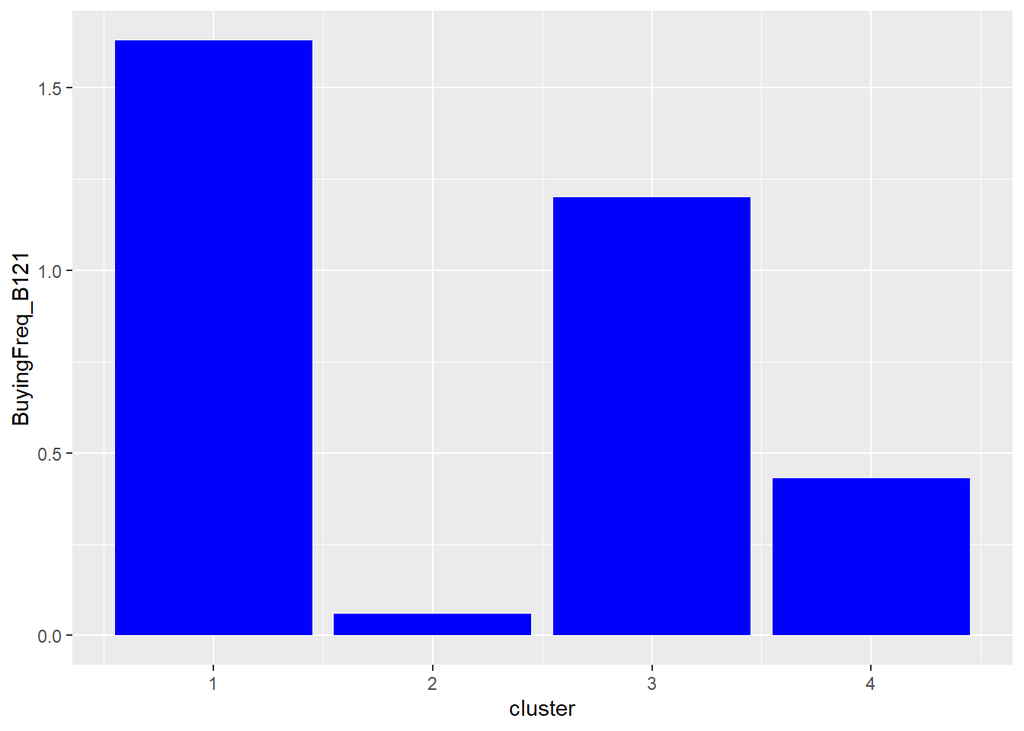

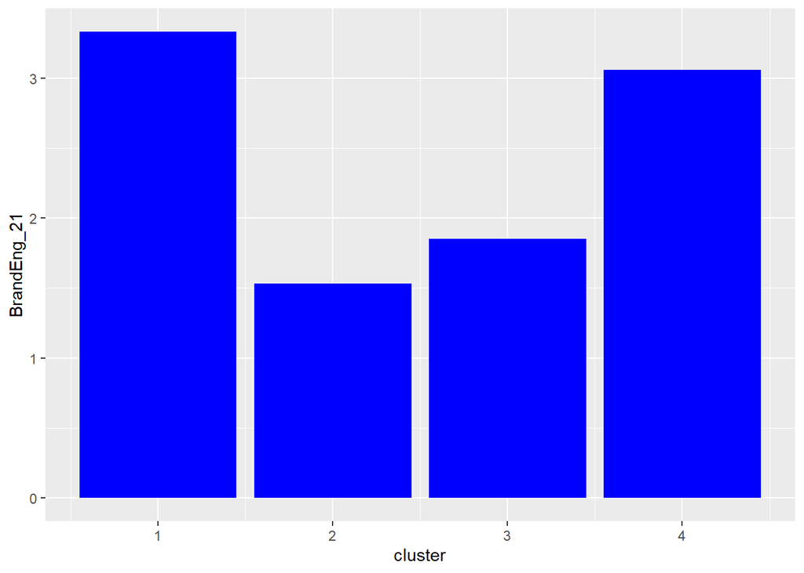

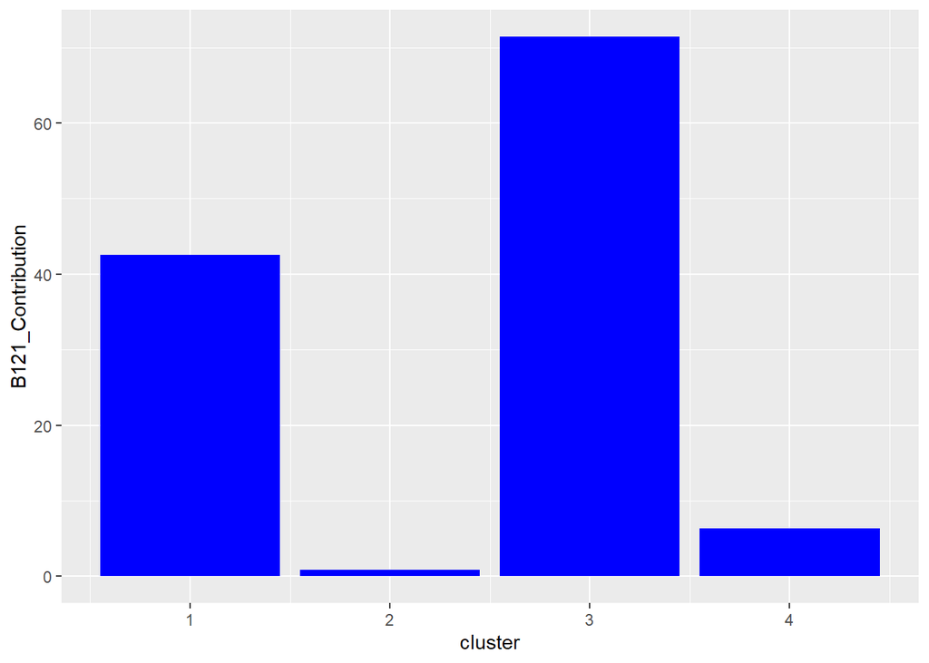

```r
par( mar= c(1,15,15,1) )
for (i in 1:6) {
  print((ggplot(allmean,aes(x=segment_mean,y=allmean[,i+1])))
        +geom_bar(stat = "identity",fill="blue")
        +labs(x="cluster",y=names(allmean)[i+1])
        )
}
```

#### Comment : Cluster one appears to be a cluster of “Platinum” customers whereas customers in cluster 2 is a group of under performers. Customers in cluster 4 are next to “Platinum” group but non-buyers of brand B1 relatively. Cluster 3 customers are mainly buying brand B1

### Using K-median method of clustering as an alternative approach to K-means as the distributions of few variables are skewed

```r
kmed4=kcca(data, k=4, family=kccaFamily("kmedians"))
```

#### Add cluster membership to the data

```r
masterdata$segment_med<-clusters(kmed4)
masterdata=data.frame(masterdata)
head(masterdata)
```

```
  CustomerID sales_21 sales_B121 BuyingFreq_21 BuyingFreq_B121 BrandEng_21
1      10000 60309.75   29684.44             3               1           4
2      10001 68859.11   26593.40             4               2           2
3      10004 69956.96    6824.23             3               1           3
4      10005  9233.57       0.00             2               0           2
5      10006 93586.85    7789.73             5               1           4
6      10008 33626.32       0.00             2               0           2
  B121_Contribution segment_mean segment_med
1         49.219969            1           1
2         38.620017            1           3
3          9.754898            4           4
4          0.000000            2           2
5          8.323530            4           1
6          0.000000            2           2
```

#### Calculate mean of each variable clusterwise and round off values to two decimal places

```r
allmed=aggregate( cbind(sales_21,sales_B121,BuyingFreq_21,BuyingFreq_B121
                      ,BrandEng_21,B121_Contribution)~segment_med,
                data=masterdata,FUN=mean)
allmed %>% map(round,2) %>% as.data.frame()
```

```
  segment_med  sales_21 sales_B121 BuyingFreq_21 BuyingFreq_B121 BrandEng_21
1           1 121787.01   37181.35          4.59            1.42        3.72
2           2  39707.18     118.02          1.97            0.04        1.69
3           3  44922.87   29973.47          2.11            1.27        1.88
4           4  78332.80    7345.21          3.47            0.68        3.12
  B121_Contribution
1             32.13
2              0.48
3             71.62
4             11.56
```

#### Summarising each variables(average value) within each cluster

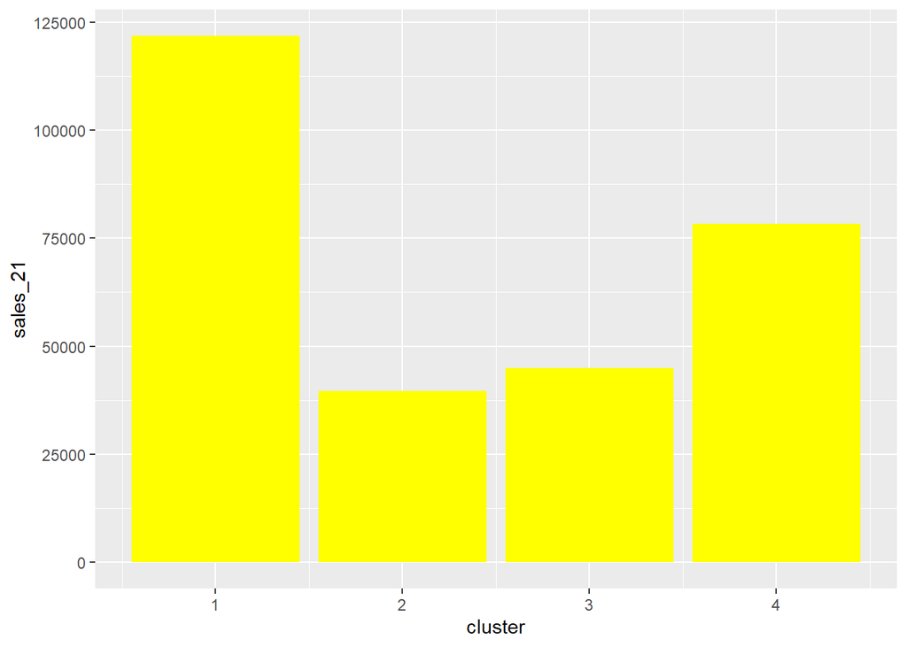

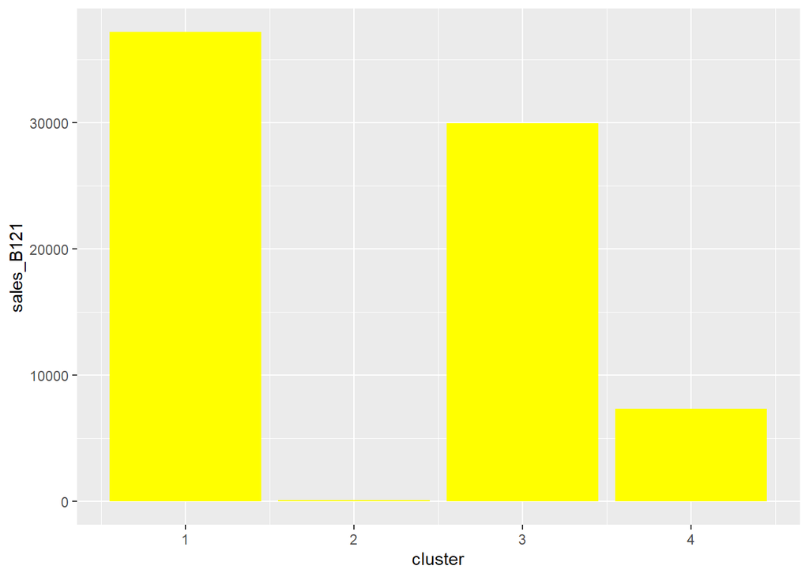

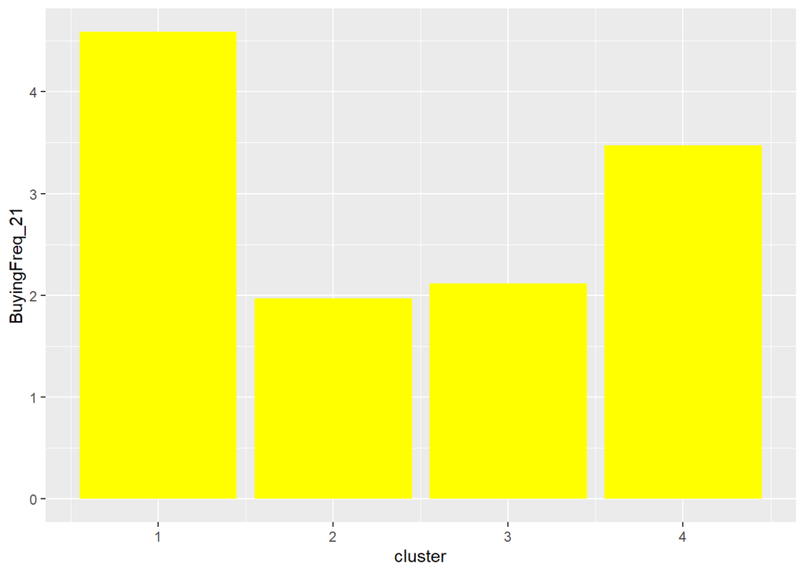

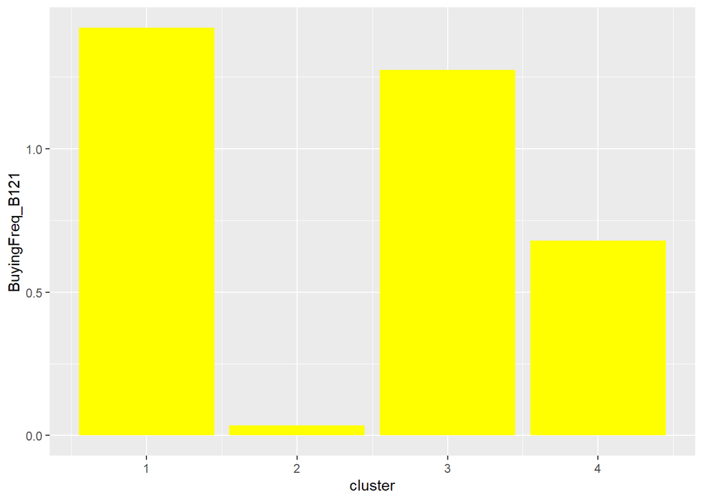

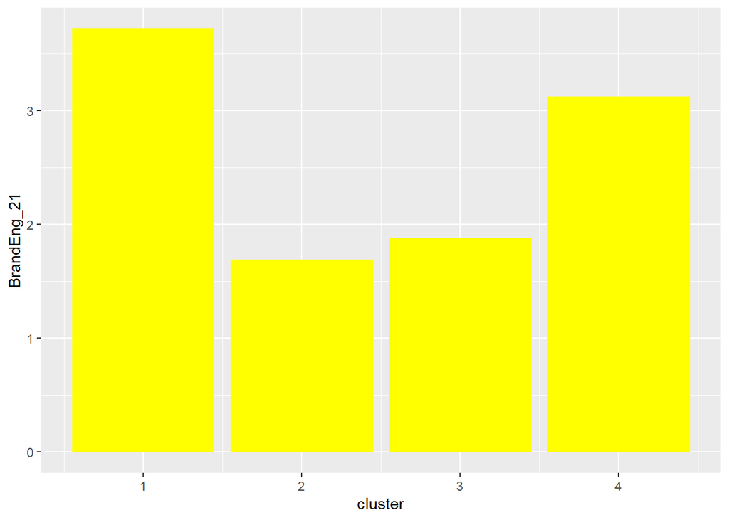

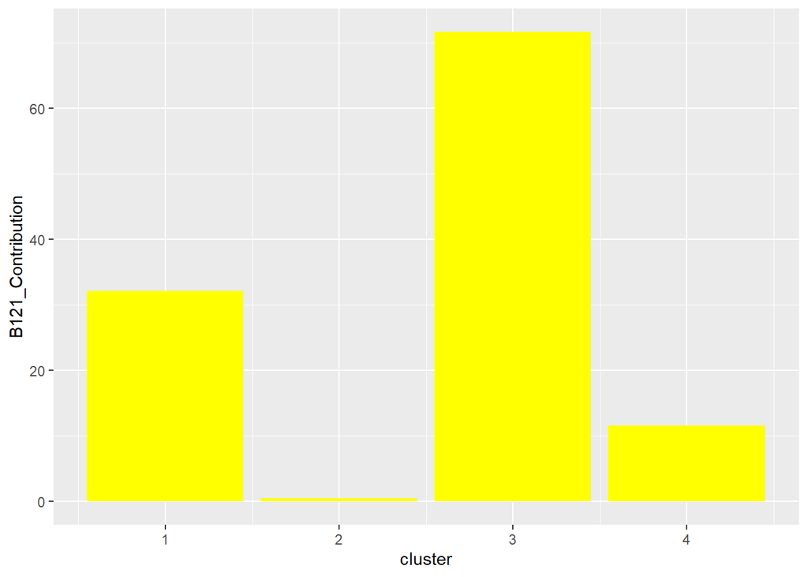

```r
par(mar=c(1,15,15,1))
for (i in 1:6) {
  print((ggplot(allmed,aes(x=segment_med,y=allmed[,i+1])))
        +geom_bar(stat = "identity",fill="yellow")
        +labs(x="cluster",y=names(allmed)[i+1])
        )
}
```

#### Comment : Cluster one appears to be a cluster of “Platinum” customers whereas customers in cluster 2 is a group of under performers. Customers in cluster 4 are next to “Platinum” group but non-buyers of brand B1 relatively. Cluster 3 customers are mainly buying brand B1